# ba_notebook

This report uses serveral statistical methods and specific phrases and concepts from the domains of statistics and machine learning. Whenever such methods are used, a small "Explanation" sign at the side of the report marks a short explanation of the methods and phrases.  
You can toggle the visibility of these explanations with a button at the top left corner of the report.

```python
import pickle
import igraph

import ba_functions as f
import ba_plot as p
import ba_descriptions as descr
import pandas as pd
import numpy as np

from tfspn.SPN import SPN
from pprint import PrettyPrinter
from IPython.display import Image
from IPython.display import display, Markdown
from importlib import reload

from plotly.offline import download_plotlyjs, init_notebook_mode, plot, iplot
from plotly.graph_objs import *

from ba_functions import printmd

init_notebook_mode(connected=True)
pp = PrettyPrinter()

# Settings
config = dict(
    rendering_detail = 100,
    high_correlation = 0.8
)
```

```python
# path to the dataset you want to use for training
dataset = 'data/titanic.csv'

# the minimum number of datapoints that are included in a child of a
# sum node
precision = 100

# the parameter which governs how strict the independece test will be
# 1 results in all features being evaluated as independent, 0 will
# result in no features being acccepted as truly independent
independence = 0.1


spn, dictionary = f.learn_spn(dataset=dataset,
                              precision=precision,
                              independence=independence,
                              isotonic=False,
                              histogram=True)
df = pd.read_csv(dataset)
categoricals = f.get_categoricals(spn)
```

```python
# path to the model pickle file
model_path = "models/test.pickle"

# UNCOMMENT THE FOLLOWING LINES TO LOAD A MODEL
#spn = SPN.from_pickle(model_path)
#dictionary = pickle.load(model_path + "_d")

#df = pd.read_csv(data_path)
```

```python
descr.introduction(spn)
```

data/titanic.csv - An automated report

This report was build on the dataset "data/titanic.csv" and contains general statistical information and an analysis on the influence different features and subgroups of the data have on each other. The first part of the report contains general statistical information about the dataset and an analysis of the variables and probability distributions.  
The second part focusses on a subgroup analysis of the data. Different clusters identified by the network are analyzed and compared to give an insight into the structure of the data. Finally the influence different variables have on the predictive capabilities of the model are analyzes.  
The whole report is generated by fitting a sum product network to the data and extracting all information from this model.

Sum product networks are graphical models which represent the distribution of data as summations and products of simple density functions. They work by exploiting context specific conditional independeces, which means that subsets of the data might have features which are independent of each other. For example, two features might produce two different clusters, which means that there is a dependency between them. But within these clusters, the variables are independent of each other.

## General statistical evaluation

```python
descr.data_description(spn, df)
```

The sum product network was build on a dataset of 712 data points. The data contains 8 features, which are "Survived", "Pclass", "Gender", "Age", "SibSp", "Parch", "Fare", "Embarked".

"Age", "Fare" are continuous features "Pclass", "SibSp", "Parch" are discrete features. Finally "Survived", "Gender", "Embarked" is a categorical feature. Continuous and dicreet features were approximated with piecewise linear density functions, while categorical features are represented by histogramms of their frequency.

To give an impression of the SPN as a whole, the complete network graph is shown below. The spn is a tree, with a sum node at its center. The root of the tree is shown in white, while the sum and product nodes are green and blue respectively. Finally, all leaves are represented by red nodes.

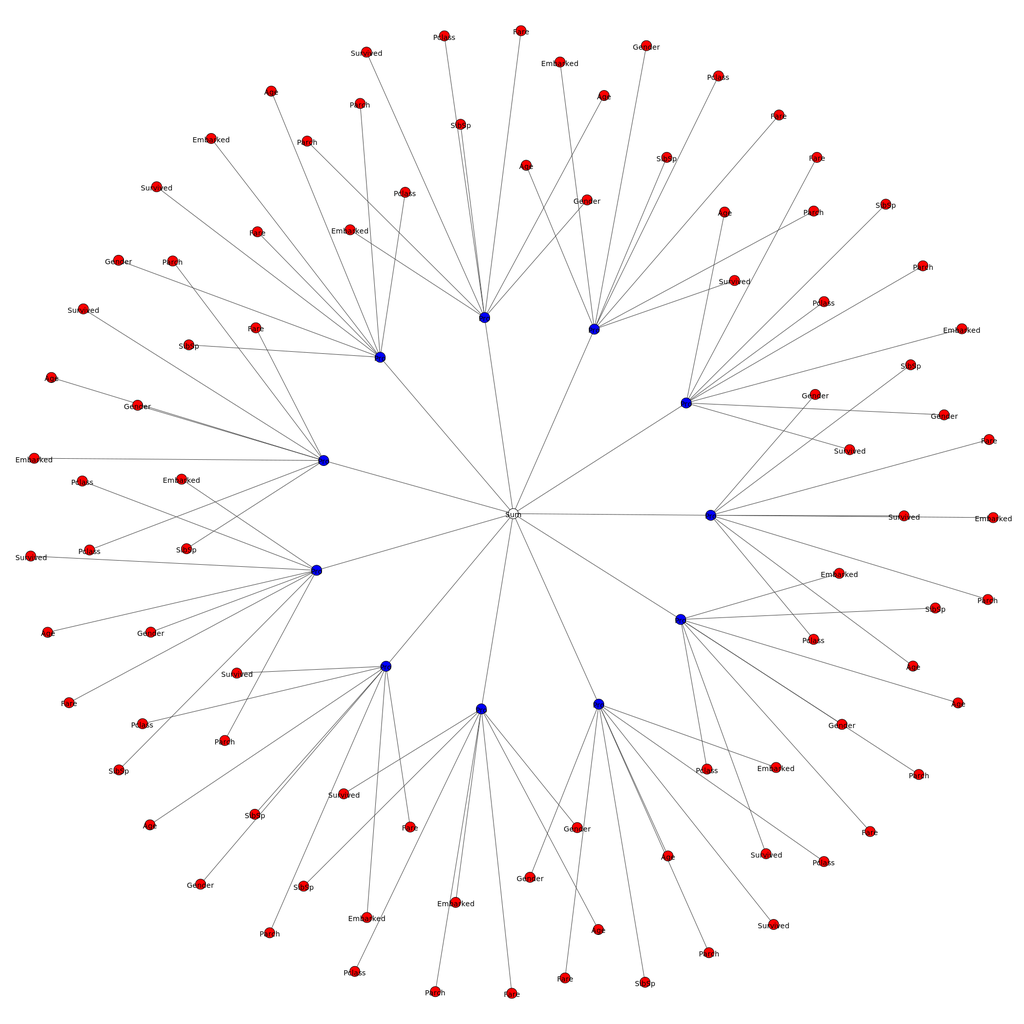

```python
graph, visual_style = p.plot_graph(spn=spn, fname="graph.png")
Image(filename='graph.png', width=600)
```

Now, the mean and standard deviation of each feature for the whole network is plotted. Categorical features do not have a mean and a standard deviation, since they contain no ordering. Instead, the network returns NaN.

```python
descr.means_table(spn)
```

[interactive chart not shown]

In the following section, the marginal distributions for each feature is shown. This is the distribution of each feature without knowing anything about the other values.

```python
reload(p)
for i in range(spn.numFeatures):
    #TODO: Fix categorical
    x = p.plot_marginal(spn, i, dictionary=dictionary)
    iplot(x)
```

[interactive chart not shown]

To get a sense of how the features relate to one another, the correlation between them is analyzed in the next section. The correlation denotes how strongly two features are linked linearly, that means, how much one increases, while another does. A high correlation (close to 1 or -1) means that two features are very closely related, while a correlation close to 0 means that there is no linear interdependency between the features.

To make it easier to grasp the dependencies quickly, the correlation is reported in a colored matrix, where blue denotes a positive and red denotes a negative correlation. The diagonal has been omitted for better readability.

```python
reload(descr)
descr.correlation_description(spn, config)
```

[interactive chart not shown]

There is a weak linear relation between "Age" and "Pclass". "Fare" and "Pclass" influence each other weakly. As one increases, the other decreases. All other features do not have more then a very weak correlation.

The conditional distributions are the probabilities of the features, given a certain instance of a class. So for example instead of calculating the distribution of heights for all humans, it is possible to compare those for different genders.

```python
reload(p)

for cat in categoricals:
    for i in range(spn.numFeatures):
        if i != cat:
            iplot(p.plot_categorical_conditional(spn, dictionary, i, cat))
```

[interactive chart not shown]

## Cluster evaluation

The root node of the SPN is a sum node. This means that for a given data point, all children of the root node report a probability, and the complete probability of that node is weighted by the relative importance of the child. The complete probability is then calculated as the sum fo these weighted child probabilities.

We can interpret these sum node children as clusters of the original data, since they are created by a clustering algorithm. These clusters capture different "sub-patterns" of the data, that we can analyse further.

```python
reload(descr)
descr.node_introduction(spn)
```

The SPN contains 11 clusters.

These are:

- a shallow ProductNode, representing 12.92% of the data.

- a shallow ProductNode, representing 10.81% of the data.

- a shallow ProductNode, representing 10.67% of the data.

- a shallow ProductNode, representing 9.83% of the data.

- a shallow ProductNode, representing 9.41% of the data.

- a shallow ProductNode, representing 9.13% of the data.

- a shallow ProductNode, representing 8.43% of the data.

- a shallow ProductNode, representing 8.29% of the data.

- a shallow ProductNode, representing 8.15% of the data.

- a shallow ProductNode, representing 7.3% of the data.

- a shallow ProductNode, representing 5.06% of the data.

The node representatives are the most likely data points for each node. They are archetypical for what the node represents and what subgroup of the data it encapsules.

[interactive chart not shown]

Shallow product nodes are nodes which split all remaining features and have only leaves as children.

```python
root = spn.root
weights_nodes = [(node, weight) for node, weight in zip(root.children, root.weights)]
weights_nodes.sort(key=lambda x: x[1])
weights_nodes.reverse()
nodes = [node[0] for node in weights_nodes]

for i, node in enumerate(nodes):
    spn.root = node
    if f.get_spn_depth(node) > 1:
        print(i)
        graph, visual_style = p.plot_graph(spn=spn, fname="node" + str(i) + ".png")
        display(Image(filename="node" + str(i) + ".png", width=200))
spn.root = root
```

As stated above, each cluster captures a subgroup of the data. To get a feeling of which subgroup was captured, the means and variances for each feature and node are plotted below. This highlights where the node has its focus.

```python
reload(p)
node_means = np.array([node.moment(1, spn.numFeatures) for node in nodes])
node_stds = np.array([np.sqrt(node.moment(2, spn.numFeatures) - node.moment(1, spn.numFeatures) ** 2)
                      for node in nodes])
names = np.arange(1,len(nodes)+1,1)
for i in range(spn.numFeatures):
    if i not in categoricals:
        plot = p.plot_error_bar(names, node_means[:,i], node_stds[:,i], spn.featureNames[i])
        iplot(plot)
```

[interactive chart not shown]

To extend the idea of which parts of the data a cluster represents, an analysis of the distribution of categorical variables is given below. If a cluster or a group of clusters capture a large fraction of the total likelihood of a categorical instance, they can be interpreted to represent this instance and the associated distribution.

```python
reload(descr)
descr.node_categorical_description(spn, dictionary)
```

Distribution of Survived

93.87% of "no" is captured by the nodes 0, 1, 4, 6, 7, 8, 9, 10. The probability of "no" for this group of nodes is 70.74%

85.22% of "yes" is captured by the nodes 0, 2, 3, 4, 5. The probability of "yes" for this group of nodes is 78.24%

Distribution of Gender

82.54% of "female" is captured by the nodes 0, 2, 3, 4, 5. The probability of "female" for this group of nodes is 73.91%

90.12% of "male" is captured by the nodes 0, 1, 4, 6, 7, 8, 9, 10. The probability of "male" for this group of nodes is 69.62%

Distribution of Embarked

The feature "Embarked" is not separated well along the primary clusters.

Finally, since each node captures different interaction between the features, it is interesting to look at the correlations again, this time for the seperate nodes. Shallow nodes are omitted, because the correlation of independent variables is always 0.

```python
root = spn.root
desc = f.get_node_description(spn, spn.root, spn.numFeatures)
high_correlation = config['high_correlation']
for i, (node, d) in enumerate(zip(nodes, desc['nodes'])):
    if not d['quick'] == 'shallow':
        printmd('### Correlations for node {}'.format(i))
        spn.root = node
        descr.correlation_description(spn, config)
        spn.root = root
```

## Classification analysis

```python
df_numerical = df.copy(deep=True)
for i in categoricals:
    transformed = dictionary['features'][i]['encoder'].transform(df_numerical.as_matrix()[:,i])
    df_numerical.iloc[:,i] = transformed

numerical_data = df_numerical.as_matrix()

categorical_data = {}
for i in categoricals:
    data = df_numerical.groupby(spn.featureNames[i])
    data = [data.get_group(x).as_matrix() for x in data.groups]
    categorical_data[i] = data
```

To evaluate the performance of the model, we count the number of occuring misclassifications for each categorical attribute and report the precision for that feature.

```python
reload(f)
misclassified = {}
data_dict = {}
for i in categoricals:
    y_true = numerical_data[:,i]
    query = np.copy(numerical_data)
    query[:,i] = np.nan
    y_pred = np.argmax(f.spn_predict_proba(spn, i, query), axis=1)
    #y_pred = spn.root.mpe_eval(query)[1][:,i]
    misclassified[i] = np.where(y_true != y_pred)[0]
    misclassified_instances = misclassified[i].shape[0]
    data_dict[i] = np.concatenate((query[:,:i], y_pred.reshape(-1,1), query[:,i+1:]), axis = 1)
    printmd('For feature "{}" the SPN misclassifies {} instances, resulting in a precision of {}%.'.format(
            spn.featureNames[i], misclassified_instances, np.round(100 * (1 - misclassified_instances/len(df)),2)))
```

For feature "Survived" the SPN misclassifies 234 instances, resulting in a precision of 67.13%.

For feature "Gender" the SPN misclassifies 213 instances, resulting in a precision of 70.08%.

For feature "Embarked" the SPN misclassifies 158 instances, resulting in a precision of 77.81%.

```python
query = np.copy(numerical_data)
y_pred = np.argmax(f.spn_predict_proba(spn, 0, query), axis=1).reshape(-1,1)
classified_data = np.append(y_pred, query[:,1:], axis = 1)
```

```python
reload(descr)
descr.explain_misclassified(spn, dictionary, misclassified, 0, classified_data, numerical_data)
```

Instance 0 is best predicted by nodes [5 6] (99.87%) which have a probability for class "yes" of 34.15%, while for class "no" the probability is 65.85%.

Instance 2 is best predicted by nodes [5] (96.39%) which have a probability for class "yes" of 68.24%, while for class "no" the probability is 31.76%.

Instance 7 is best predicted by nodes [0 3] (93.75%) which have a probability for class "yes" of 66.08%, while for class "no" the probability is 33.92%.

Instance 11 is best predicted by nodes [2 1] (90.97%) which have a probability for class "yes" of 60.88%, while for class "no" the probability is 39.12%.

Instance 13 is best predicted by nodes [3] (98.59%) which have a probability for class "yes" of 83.0%, while for class "no" the probability is 17.0%.

Instance 16 is best predicted by nodes [5] (93.37%) which have a probability for class "yes" of 68.24%, while for class "no" the probability is 31.76%.

Instance 17 is best predicted by nodes [2 1 0 8] (98.37%) which have a probability for class "yes" of 49.49%, while for class "no" the probability is 50.51%.

Instance 28 is best predicted by nodes [3] (99.86%) which have a probability for class "yes" of 83.0%, while for class "no" the probability is 17.0%.

Instance 35 is best predicted by nodes [5 9] (92.12%) which have a probability for class "yes" of 31.89%, while for class "no" the probability is 68.11%.

Instance 36 is best predicted by nodes [5] (95.36%) which have a probability for class "yes" of 68.24%, while for class "no" the probability is 31.76%.

Instance 38 is best predicted by nodes [5] (95.88%) which have a probability for class "yes" of 68.24%, while for class "no" the probability is 31.76%.

Instance 41 is best predicted by nodes [3] (99.97%) which have a probability for class "yes" of 83.0%, while for class "no" the probability is 17.0%.

Instance 43 is best predicted by nodes [3] (99.73%) which have a probability for class "yes" of 83.0%, while for class "no" the probability is 17.0%.

Instance 54 is best predicted by nodes [3] (99.67%) which have a probability for class "yes" of 83.0%, while for class "no" the probability is 17.0%.

Instance 57 is best predicted by nodes [3 6] (99.28%) which have a probability for class "yes" of 51.78%, while for class "no" the probability is 48.22%.

Instance 59 is best predicted by nodes [0 3 4 1] (94.88%) which have a probability for class "yes" of 48.69%, while for class "no" the probability is 51.31%.

Instance 74 is best predicted by nodes [5] (95.88%) which have a probability for class "yes" of 68.24%, while for class "no" the probability is 31.76%.

Instance 95 is best predicted by nodes [2] (96.62%) which have a probability for class "yes" of 98.45%, while for class "no" the probability is 1.55%.

Instance 96 is best predicted by nodes [2] (96.44%) which have a probability for class "yes" of 98.45%, while for class "no" the probability is 1.55%.

Instance 98 is best predicted by nodes [5] (95.16%) which have a probability for class "yes" of 68.24%, while for class "no" the probability is 31.76%.

Instance 107 is best predicted by nodes [2] (95.99%) which have a probability for class "yes" of 98.45%, while for class "no" the probability is 1.55%.

Instance 116 is best predicted by nodes [4 5] (92.29%) which have a probability for class "yes" of 54.97%, while for class "no" the probability is 45.03%.

Instance 119 is best predicted by nodes [2 6] (91.37%) which have a probability for class "yes" of 64.01%, while for class "no" the probability is 35.99%.

Instance 121 is best predicted by nodes [0 3] (96.86%) which have a probability for class "yes" of 66.08%, while for class "no" the probability is 33.92%.

Instance 128 is best predicted by nodes [5 9] (91.63%) which have a probability for class "yes" of 31.89%, while for class "no" the probability is 68.11%.

Instance 133 is best predicted by nodes [3] (99.74%) which have a probability for class "yes" of 83.0%, while for class "no" the probability is 17.0%.

Instance 136 is best predicted by nodes [3] (99.15%) which have a probability for class "yes" of 83.0%, while for class "no" the probability is 17.0%.

Instance 138 is best predicted by nodes [0 4 3] (96.77%) which have a probability for class "yes" of 60.53%, while for class "no" the probability is 39.47%.

Instance 144 is best predicted by nodes [3 0 7] (98.16%) which have a probability for class "yes" of 49.87%, while for class "no" the probability is 50.13%.

Instance 146 is best predicted by nodes [1 2] (92.18%) which have a probability for class "yes" of 60.88%, while for class "no" the probability is 39.12%.

Instance 147 is best predicted by nodes [0] (91.96%) which have a probability for class "yes" of 49.37%, while for class "no" the probability is 50.63%.

Instance 158 is best predicted by nodes [2 1 0] (92.96%) which have a probability for class "yes" of 57.17%, while for class "no" the probability is 42.83%.

Instance 164 is best predicted by nodes [3] (99.43%) which have a probability for class "yes" of 83.0%, while for class "no" the probability is 17.0%.

Instance 166 is best predicted by nodes [2] (93.56%) which have a probability for class "yes" of 98.45%, while for class "no" the probability is 1.55%.

Instance 170 is best predicted by nodes [3 6] (99.53%) which have a probability for class "yes" of 51.78%, while for class "no" the probability is 48.22%.

Instance 173 is best predicted by nodes [5 8] (92.63%) which have a probability for class "yes" of 37.26%, while for class "no" the probability is 62.74%.

Instance 178 is best predicted by nodes [5] (99.97%) which have a probability for class "yes" of 68.24%, while for class "no" the probability is 31.76%.

Instance 180 is best predicted by nodes [5 6] (99.97%) which have a probability for class "yes" of 34.15%, while for class "no" the probability is 65.85%.

Instance 183 is best predicted by nodes [5] (96.53%) which have a probability for class "yes" of 68.24%, while for class "no" the probability is 31.76%.

Instance 186 is best predicted by nodes [5] (97.93%) which have a probability for class "yes" of 68.24%, while for class "no" the probability is 31.76%.

Instance 192 is best predicted by nodes [3 4] (98.09%) which have a probability for class "yes" of 66.53%, while for class "no" the probability is 33.47%.

Instance 194 is best predicted by nodes [2] (99.93%) which have a probability for class "yes" of 98.45%, while for class "no" the probability is 1.55%.

Instance 197 is best predicted by nodes [4 3 0 1] (98.8%) which have a probability for class "yes" of 48.69%, while for class "no" the probability is 51.31%.

Instance 198 is best predicted by nodes [0 1 2] (95.95%) which have a probability for class "yes" of 57.17%, while for class "no" the probability is 42.83%.

Instance 206 is best predicted by nodes [5] (99.9%) which have a probability for class "yes" of 68.24%, while for class "no" the probability is 31.76%.

Instance 209 is best predicted by nodes [5] (92.7%) which have a probability for class "yes" of 68.24%, while for class "no" the probability is 31.76%.

Instance 214 is best predicted by nodes [ 5 10 8] (96.4%) which have a probability for class "yes" of 26.85%, while for class "no" the probability is 73.15%.

Instance 217 is best predicted by nodes [5] (96.06%) which have a probability for class "yes" of 68.24%, while for class "no" the probability is 31.76%.

Instance 218 is best predicted by nodes [3] (100.0%) which have a probability for class "yes" of 83.0%, while for class "no" the probability is 17.0%.

Instance 221 is best predicted by nodes [5] (99.88%) which have a probability for class "yes" of 68.24%, while for class "no" the probability is 31.76%.

Instance 222 is best predicted by nodes [5 6 8] (91.75%) which have a probability for class "yes" of 28.33%, while for class "no" the probability is 71.67%.

Instance 223 is best predicted by nodes [3] (99.58%) which have a probability for class "yes" of 83.0%, while for class "no" the probability is 17.0%.

Instance 228 is best predicted by nodes [5 9] (91.63%) which have a probability for class "yes" of 31.89%, while for class "no" the probability is 68.11%.

Instance 240 is best predicted by nodes [2 0 6] (96.63%) which have a probability for class "yes" of 59.2%, while for class "no" the probability is 40.8%.

Instance 252 is best predicted by nodes [5 9] (92.12%) which have a probability for class "yes" of 31.89%, while for class "no" the probability is 68.11%.

Instance 266 is best predicted by nodes [2] (93.98%) which have a probability for class "yes" of 98.45%, while for class "no" the probability is 1.55%.

Instance 267 is best predicted by nodes [5] (96.07%) which have a probability for class "yes" of 68.24%, while for class "no" the probability is 31.76%.

Instance 268 is best predicted by nodes [5] (94.28%) which have a probability for class "yes" of 68.24%, while for class "no" the probability is 31.76%.

Instance 280 is best predicted by nodes [5] (96.69%) which have a probability for class "yes" of 68.24%, while for class "no" the probability is 31.76%.

Instance 282 is best predicted by nodes [3 9] (99.89%) which have a probability for class "yes" of 50.83%, while for class "no" the probability is 49.17%.

Instance 285 is best predicted by nodes [0] (97.5%) which have a probability for class "yes" of 49.37%, while for class "no" the probability is 50.63%.

Instance 293 is best predicted by nodes [2 0] (92.27%) which have a probability for class "yes" of 76.09%, while for class "no" the probability is 23.91%.

Instance 300 is best predicted by nodes [3] (99.31%) which have a probability for class "yes" of 83.0%, while for class "no" the probability is 17.0%.

Instance 310 is best predicted by nodes [5 6] (99.63%) which have a probability for class "yes" of 34.15%, while for class "no" the probability is 65.85%.

Instance 331 is best predicted by nodes [0] (97.67%) which have a probability for class "yes" of 49.37%, while for class "no" the probability is 50.63%.

Instance 333 is best predicted by nodes [3] (93.16%) which have a probability for class "yes" of 83.0%, while for class "no" the probability is 17.0%.

Instance 346 is best predicted by nodes [2 0] (99.03%) which have a probability for class "yes" of 76.09%, while for class "no" the probability is 23.91%.

Instance 348 is best predicted by nodes [0 2 1] (92.81%) which have a probability for class "yes" of 57.17%, while for class "no" the probability is 42.83%.

Instance 357 is best predicted by nodes [4 2 8] (93.85%) which have a probability for class "yes" of 61.22%, while for class "no" the probability is 38.78%.

Instance 365 is best predicted by nodes [2 1] (90.32%) which have a probability for class "yes" of 60.88%, while for class "no" the probability is 39.12%.

Instance 369 is best predicted by nodes [0 1 4 2 3] (99.61%) which have a probability for class "yes" of 60.67%, while for class "no" the probability is 39.33%.

Instance 376 is best predicted by nodes [5] (97.13%) which have a probability for class "yes" of 68.24%, while for class "no" the probability is 31.76%.

Instance 383 is best predicted by nodes [2 1 8 0] (90.92%) which have a probability for class "yes" of 49.49%, while for class "no" the probability is 50.51%.

Instance 387 is best predicted by nodes [0 3] (93.53%) which have a probability for class "yes" of 66.08%, while for class "no" the probability is 33.92%.

Instance 389 is best predicted by nodes [5 3] (92.75%) which have a probability for class "yes" of 78.25%, while for class "no" the probability is 21.75%.

Instance 398 is best predicted by nodes [5] (99.2%) which have a probability for class "yes" of 68.24%, while for class "no" the probability is 31.76%.

Instance 399 is best predicted by nodes [2] (95.72%) which have a probability for class "yes" of 98.45%, while for class "no" the probability is 1.55%.

Instance 402 is best predicted by nodes [2] (96.44%) which have a probability for class "yes" of 98.45%, while for class "no" the probability is 1.55%.

Instance 404 is best predicted by nodes [0] (98.45%) which have a probability for class "no" of 50.63%, while for class "yes" the probability is 49.37%.

Instance 409 is best predicted by nodes [6] (96.77%) which have a probability for class "no" of 84.72%, while for class "yes" the probability is 15.28%.

Instance 410 is best predicted by nodes [1 6] (93.43%) which have a probability for class "no" of 86.68%, while for class "yes" the probability is 13.32%.

Instance 411 is best predicted by nodes [4] (98.86%) which have a probability for class "no" of 52.15%, while for class "yes" the probability is 47.85%.

Instance 412 is best predicted by nodes [8] (99.15%) which have a probability for class "no" of 81.65%, while for class "yes" the probability is 18.35%.

Instance 413 is best predicted by nodes [8] (99.78%) which have a probability for class "no" of 81.65%, while for class "yes" the probability is 18.35%.

Instance 414 is best predicted by nodes [6 2] (99.9%) which have a probability for class "no" of 35.99%, while for class "yes" the probability is 64.01%.

Instance 415 is best predicted by nodes [5 4 8 6] (95.02%) which have a probability for class "no" of 65.91%, while for class "yes" the probability is 34.09%.

Instance 420 is best predicted by nodes [1 6 8 0 5] (92.25%) which have a probability for class "no" of 70.23%, while for class "yes" the probability is 29.77%.

Instance 421 is best predicted by nodes [4] (94.24%) which have a probability for class "no" of 52.15%, while for class "yes" the probability is 47.85%.

Instance 422 is best predicted by nodes [9] (94.42%) which have a probability for class "no" of 89.92%, while for class "yes" the probability is 10.08%.

Instance 426 is best predicted by nodes [9 3] (93.91%) which have a probability for class "no" of 49.17%, while for class "yes" the probability is 50.83%.

Instance 427 is best predicted by nodes [8 9 6] (97.31%) which have a probability for class "no" of 85.43%, while for class "yes" the probability is 14.57%.

Instance 429 is best predicted by nodes [6] (99.84%) which have a probability for class "no" of 84.72%, while for class "yes" the probability is 15.28%.

Instance 430 is best predicted by nodes [6 3 0 8 5 2] (94.38%) which have a probability for class "no" of 41.48%, while for class "yes" the probability is 58.52%.

Instance 431 is best predicted by nodes [4] (99.84%) which have a probability for class "no" of 52.15%, while for class "yes" the probability is 47.85%.

Instance 432 is best predicted by nodes [4] (98.3%) which have a probability for class "no" of 52.15%, while for class "yes" the probability is 47.85%.

Instance 433 is best predicted by nodes [4] (99.46%) which have a probability for class "no" of 52.15%, while for class "yes" the probability is 47.85%.

Instance 434 is best predicted by nodes [4] (99.44%) which have a probability for class "no" of 52.15%, while for class "yes" the probability is 47.85%.

Instance 435 is best predicted by nodes [0] (93.7%) which have a probability for class "no" of 50.63%, while for class "yes" the probability is 49.37%.

Instance 436 is best predicted by nodes [1 6 8 0 5] (92.62%) which have a probability for class "no" of 70.23%, while for class "yes" the probability is 29.77%.

Instance 437 is best predicted by nodes [5 6] (99.98%) which have a probability for class "no" of 65.85%, while for class "yes" the probability is 34.15%.

Instance 438 is best predicted by nodes [4] (96.04%) which have a probability for class "no" of 52.15%, while for class "yes" the probability is 47.85%.

Instance 440 is best predicted by nodes [0] (98.94%) which have a probability for class "no" of 50.63%, while for class "yes" the probability is 49.37%.

Instance 441 is best predicted by nodes [6] (92.64%) which have a probability for class "no" of 84.72%, while for class "yes" the probability is 15.28%.

Instance 442 is best predicted by nodes [9] (96.73%) which have a probability for class "no" of 89.92%, while for class "yes" the probability is 10.08%.

Instance 443 is best predicted by nodes [6] (99.84%) which have a probability for class "no" of 84.72%, while for class "yes" the probability is 15.28%.

Instance 445 is best predicted by nodes [3 0 1 6 5] (92.45%) which have a probability for class "no" of 55.67%, while for class "yes" the probability is 44.33%.

Instance 447 is best predicted by nodes [8 5 6] (93.74%) which have a probability for class "no" of 71.67%, while for class "yes" the probability is 28.33%.

Instance 449 is best predicted by nodes [6] (99.87%) which have a probability for class "no" of 84.72%, while for class "yes" the probability is 15.28%.

Instance 451 is best predicted by nodes [6] (92.36%) which have a probability for class "no" of 84.72%, while for class "yes" the probability is 15.28%.

Instance 453 is best predicted by nodes [4] (99.98%) which have a probability for class "no" of 52.15%, while for class "yes" the probability is 47.85%.

Instance 457 is best predicted by nodes [8 2] (98.5%) which have a probability for class "no" of 32.85%, while for class "yes" the probability is 67.15%.

Instance 459 is best predicted by nodes [1] (94.92%) which have a probability for class "no" of 88.5%, while for class "yes" the probability is 11.5%.

Instance 460 is best predicted by nodes [0] (99.77%) which have a probability for class "no" of 50.63%, while for class "yes" the probability is 49.37%.

Instance 461 is best predicted by nodes [4] (100.0%) which have a probability for class "no" of 52.15%, while for class "yes" the probability is 47.85%.

Instance 462 is best predicted by nodes [9] (99.9%) which have a probability for class "no" of 89.92%, while for class "yes" the probability is 10.08%.

Instance 463 is best predicted by nodes [0] (98.38%) which have a probability for class "no" of 50.63%, while for class "yes" the probability is 49.37%.

Instance 464 is best predicted by nodes [1 3 0] (98.59%) which have a probability for class "no" of 51.05%, while for class "yes" the probability is 48.95%.

Instance 465 is best predicted by nodes [10 7] (96.41%) which have a probability for class "no" of 92.55%, while for class "yes" the probability is 7.45%.

Instance 467 is best predicted by nodes [0] (98.18%) which have a probability for class "no" of 50.63%, while for class "yes" the probability is 49.37%.

Instance 468 is best predicted by nodes [4 5] (95.26%) which have a probability for class "no" of 45.03%, while for class "yes" the probability is 54.97%.

Instance 469 is best predicted by nodes [6] (92.43%) which have a probability for class "no" of 84.72%, while for class "yes" the probability is 15.28%.

Instance 470 is best predicted by nodes [8] (99.55%) which have a probability for class "no" of 81.65%, while for class "yes" the probability is 18.35%.

Instance 471 is best predicted by nodes [6 8 9 0] (91.47%) which have a probability for class "no" of 75.16%, while for class "yes" the probability is 24.84%.

Instance 481 is best predicted by nodes [9] (97.84%) which have a probability for class "no" of 89.92%, while for class "yes" the probability is 10.08%.

Instance 485 is best predicted by nodes [8] (93.19%) which have a probability for class "no" of 81.65%, while for class "yes" the probability is 18.35%.

Instance 488 is best predicted by nodes [1 6 8 0 5 2] (93.6%) which have a probability for class "no" of 54.4%, while for class "yes" the probability is 45.6%.

Instance 492 is best predicted by nodes [9 8 6] (94.81%) which have a probability for class "no" of 85.43%, while for class "yes" the probability is 14.57%.

Instance 493 is best predicted by nodes [4] (97.38%) which have a probability for class "no" of 52.15%, while for class "yes" the probability is 47.85%.

Instance 495 is best predicted by nodes [9 3] (99.04%) which have a probability for class "no" of 49.17%, while for class "yes" the probability is 50.83%.

Instance 496 is best predicted by nodes [6 8 0 5 2 3] (95.07%) which have a probability for class "no" of 41.48%, while for class "yes" the probability is 58.52%.

Instance 497 is best predicted by nodes [4] (99.97%) which have a probability for class "no" of 52.15%, while for class "yes" the probability is 47.85%.

Instance 499 is best predicted by nodes [0] (98.17%) which have a probability for class "no" of 50.63%, while for class "yes" the probability is 49.37%.

Instance 504 is best predicted by nodes [4] (99.8%) which have a probability for class "no" of 52.15%, while for class "yes" the probability is 47.85%.

Instance 506 is best predicted by nodes [1 6 8 0 5 2] (93.6%) which have a probability for class "no" of 54.4%, while for class "yes" the probability is 45.6%.

Instance 507 is best predicted by nodes [6] (93.35%) which have a probability for class "no" of 84.72%, while for class "yes" the probability is 15.28%.

Instance 512 is best predicted by nodes [8 2] (99.76%) which have a probability for class "no" of 32.85%, while for class "yes" the probability is 67.15%.

Instance 513 is best predicted by nodes [9 8 6] (93.26%) which have a probability for class "no" of 85.43%, while for class "yes" the probability is 14.57%.

Instance 514 is best predicted by nodes [4] (97.92%) which have a probability for class "no" of 52.15%, while for class "yes" the probability is 47.85%.

Instance 515 is best predicted by nodes [1 3 0] (99.27%) which have a probability for class "no" of 51.05%, while for class "yes" the probability is 48.95%.

Instance 516 is best predicted by nodes [9 8 6] (94.78%) which have a probability for class "no" of 85.43%, while for class "yes" the probability is 14.57%.

Instance 520 is best predicted by nodes [6 3] (95.81%) which have a probability for class "no" of 48.22%, while for class "yes" the probability is 51.78%.

Instance 521 is best predicted by nodes [9 8 6] (97.35%) which have a probability for class "no" of 85.43%, while for class "yes" the probability is 14.57%.

Instance 522 is best predicted by nodes [1 2 0] (93.4%) which have a probability for class "no" of 42.83%, while for class "yes" the probability is 57.17%.

Instance 527 is best predicted by nodes [8 2] (99.76%) which have a probability for class "no" of 32.85%, while for class "yes" the probability is 67.15%.

Instance 530 is best predicted by nodes [0 1] (96.48%) which have a probability for class "no" of 68.66%, while for class "yes" the probability is 31.34%.

Instance 531 is best predicted by nodes [4] (99.77%) which have a probability for class "no" of 52.15%, while for class "yes" the probability is 47.85%.

Instance 532 is best predicted by nodes [0] (99.98%) which have a probability for class "no" of 50.63%, while for class "yes" the probability is 49.37%.

Instance 533 is best predicted by nodes [0] (99.73%) which have a probability for class "no" of 50.63%, while for class "yes" the probability is 49.37%.

Instance 534 is best predicted by nodes [8] (99.94%) which have a probability for class "no" of 81.65%, while for class "yes" the probability is 18.35%.

Instance 536 is best predicted by nodes [0] (99.98%) which have a probability for class "no" of 50.63%, while for class "yes" the probability is 49.37%.

Instance 537 is best predicted by nodes [4] (99.96%) which have a probability for class "no" of 52.15%, while for class "yes" the probability is 47.85%.

Instance 540 is best predicted by nodes [4] (99.78%) which have a probability for class "no" of 52.15%, while for class "yes" the probability is 47.85%.

Instance 544 is best predicted by nodes [4] (99.94%) which have a probability for class "no" of 52.15%, while for class "yes" the probability is 47.85%.

Instance 545 is best predicted by nodes [0] (98.53%) which have a probability for class "no" of 50.63%, while for class "yes" the probability is 49.37%.

Instance 548 is best predicted by nodes [9] (91.31%) which have a probability for class "no" of 89.92%, while for class "yes" the probability is 10.08%.

Instance 549 is best predicted by nodes [8] (99.97%) which have a probability for class "no" of 81.65%, while for class "yes" the probability is 18.35%.

Instance 550 is best predicted by nodes [0 1] (95.37%) which have a probability for class "no" of 68.66%, while for class "yes" the probability is 31.34%.

Instance 551 is best predicted by nodes [0] (98.24%) which have a probability for class "no" of 50.63%, while for class "yes" the probability is 49.37%.

Instance 562 is best predicted by nodes [1 0] (92.87%) which have a probability for class "no" of 68.66%, while for class "yes" the probability is 31.34%.

Instance 566 is best predicted by nodes [10 8 6] (99.54%) which have a probability for class "no" of 85.89%, while for class "yes" the probability is 14.11%.

Instance 568 is best predicted by nodes [0] (99.8%) which have a probability for class "no" of 50.63%, while for class "yes" the probability is 49.37%.

Instance 570 is best predicted by nodes [5 6 4 8 1] (94.24%) which have a probability for class "no" of 71.24%, while for class "yes" the probability is 28.76%.

Instance 571 is best predicted by nodes [9 8 6] (97.41%) which have a probability for class "no" of 85.43%, while for class "yes" the probability is 14.57%.

Instance 573 is best predicted by nodes [0] (99.41%) which have a probability for class "no" of 50.63%, while for class "yes" the probability is 49.37%.

Instance 574 is best predicted by nodes [0 1] (95.33%) which have a probability for class "no" of 68.66%, while for class "yes" the probability is 31.34%.

Instance 575 is best predicted by nodes [1 6 8 0 5] (90.89%) which have a probability for class "no" of 70.23%, while for class "yes" the probability is 29.77%.

Instance 577 is best predicted by nodes [9 8 6] (97.49%) which have a probability for class "no" of 85.43%, while for class "yes" the probability is 14.57%.

Instance 581 is best predicted by nodes [0] (99.2%) which have a probability for class "no" of 50.63%, while for class "yes" the probability is 49.37%.

Instance 582 is best predicted by nodes [0] (98.56%) which have a probability for class "no" of 50.63%, while for class "yes" the probability is 49.37%.

Instance 583 is best predicted by nodes [0] (99.61%) which have a probability for class "no" of 50.63%, while for class "yes" the probability is 49.37%.

Instance 585 is best predicted by nodes [0 1] (95.59%) which have a probability for class "no" of 68.66%, while for class "yes" the probability is 31.34%.

Instance 592 is best predicted by nodes [6 5] (96.16%) which have a probability for class "no" of 65.85%, while for class "yes" the probability is 34.15%.

Instance 595 is best predicted by nodes [0 1] (94.95%) which have a probability for class "no" of 68.66%, while for class "yes" the probability is 31.34%.

Instance 596 is best predicted by nodes [8 2] (99.76%) which have a probability for class "no" of 32.85%, while for class "yes" the probability is 67.15%.

Instance 598 is best predicted by nodes [4] (99.96%) which have a probability for class "no" of 52.15%, while for class "yes" the probability is 47.85%.

Instance 599 is best predicted by nodes [0] (99.57%) which have a probability for class "no" of 50.63%, while for class "yes" the probability is 49.37%.

Instance 600 is best predicted by nodes [0] (99.98%) which have a probability for class "no" of 50.63%, while for class "yes" the probability is 49.37%.

Instance 601 is best predicted by nodes [9] (98.45%) which have a probability for class "no" of 89.92%, while for class "yes" the probability is 10.08%.

Instance 603 is best predicted by nodes [0] (99.54%) which have a probability for class "no" of 50.63%, while for class "yes" the probability is 49.37%.

Instance 604 is best predicted by nodes [6 5] (99.76%) which have a probability for class "no" of 65.85%, while for class "yes" the probability is 34.15%.

Instance 606 is best predicted by nodes [1 2 6] (92.76%) which have a probability for class "no" of 52.18%, while for class "yes" the probability is 47.82%.

Instance 608 is best predicted by nodes [1] (96.81%) which have a probability for class "no" of 88.5%, while for class "yes" the probability is 11.5%.

Instance 611 is best predicted by nodes [1 2] (91.04%) which have a probability for class "no" of 39.12%, while for class "yes" the probability is 60.88%.

Instance 612 is best predicted by nodes [4] (99.74%) which have a probability for class "no" of 52.15%, while for class "yes" the probability is 47.85%.

Instance 614 is best predicted by nodes [0 1] (96.03%) which have a probability for class "no" of 68.66%, while for class "yes" the probability is 31.34%.

Instance 615 is best predicted by nodes [6 8 0 5 2 3] (95.32%) which have a probability for class "no" of 41.48%, while for class "yes" the probability is 58.52%.

Instance 616 is best predicted by nodes [0] (93.47%) which have a probability for class "no" of 50.63%, while for class "yes" the probability is 49.37%.

Instance 619 is best predicted by nodes [0] (99.89%) which have a probability for class "no" of 50.63%, while for class "yes" the probability is 49.37%.

Instance 626 is best predicted by nodes [1] (98.72%) which have a probability for class "no" of 88.5%, while for class "yes" the probability is 11.5%.

Instance 628 is best predicted by nodes [9 8 6] (97.44%) which have a probability for class "no" of 85.43%, while for class "yes" the probability is 14.57%.

Instance 629 is best predicted by nodes [8 2] (99.41%) which have a probability for class "no" of 32.85%, while for class "yes" the probability is 67.15%.

Instance 631 is best predicted by nodes [4] (99.45%) which have a probability for class "no" of 52.15%, while for class "yes" the probability is 47.85%.

Instance 633 is best predicted by nodes [4] (99.56%) which have a probability for class "no" of 52.15%, while for class "yes" the probability is 47.85%.

Instance 634 is best predicted by nodes [1 3 0] (99.37%) which have a probability for class "no" of 51.05%, while for class "yes" the probability is 48.95%.

Instance 635 is best predicted by nodes [6] (98.68%) which have a probability for class "no" of 84.72%, while for class "yes" the probability is 15.28%.

Instance 637 is best predicted by nodes [0] (98.91%) which have a probability for class "no" of 50.63%, while for class "yes" the probability is 49.37%.

Instance 638 is best predicted by nodes [0] (99.7%) which have a probability for class "no" of 50.63%, while for class "yes" the probability is 49.37%.

Instance 639 is best predicted by nodes [4] (90.75%) which have a probability for class "no" of 52.15%, while for class "yes" the probability is 47.85%.

Instance 641 is best predicted by nodes [8 6] (97.53%) which have a probability for class "no" of 83.26%, while for class "yes" the probability is 16.74%.

Instance 643 is best predicted by nodes [5 6] (99.98%) which have a probability for class "no" of 65.85%, while for class "yes" the probability is 34.15%.

Instance 644 is best predicted by nodes [4] (99.98%) which have a probability for class "no" of 52.15%, while for class "yes" the probability is 47.85%.

Instance 645 is best predicted by nodes [0] (99.95%) which have a probability for class "no" of 50.63%, while for class "yes" the probability is 49.37%.

Instance 646 is best predicted by nodes [5 8 6] (93.95%) which have a probability for class "no" of 71.67%, while for class "yes" the probability is 28.33%.

Instance 649 is best predicted by nodes [8 6 9 4] (94.45%) which have a probability for class "no" of 76.55%, while for class "yes" the probability is 23.45%.

Instance 650 is best predicted by nodes [8 6] (99.29%) which have a probability for class "no" of 83.26%, while for class "yes" the probability is 16.74%.

Instance 653 is best predicted by nodes [9 8 6] (96.53%) which have a probability for class "no" of 85.43%, while for class "yes" the probability is 14.57%.

Instance 655 is best predicted by nodes [4] (95.08%) which have a probability for class "no" of 52.15%, while for class "yes" the probability is 47.85%.

Instance 656 is best predicted by nodes [4 6] (97.16%) which have a probability for class "no" of 68.19%, while for class "yes" the probability is 31.81%.

Instance 657 is best predicted by nodes [4] (99.81%) which have a probability for class "no" of 52.15%, while for class "yes" the probability is 47.85%.

Instance 659 is best predicted by nodes [1 6] (93.43%) which have a probability for class "no" of 86.68%, while for class "yes" the probability is 13.32%.

Instance 664 is best predicted by nodes [0] (99.99%) which have a probability for class "no" of 50.63%, while for class "yes" the probability is 49.37%.

Instance 666 is best predicted by nodes [0] (99.93%) which have a probability for class "no" of 50.63%, while for class "yes" the probability is 49.37%.

Instance 667 is best predicted by nodes [6 8 0 5 2] (90.13%) which have a probability for class "no" of 47.14%, while for class "yes" the probability is 52.86%.

Instance 669 is best predicted by nodes [4] (99.83%) which have a probability for class "no" of 52.15%, while for class "yes" the probability is 47.85%.

Instance 672 is best predicted by nodes [6] (99.54%) which have a probability for class "no" of 84.72%, while for class "yes" the probability is 15.28%.

Instance 685 is best predicted by nodes [2 5 6] (91.65%) which have a probability for class "yes" of 64.8%, while for class "no" the probability is 35.2%.

Instance 688 is best predicted by nodes [3] (96.71%) which have a probability for class "yes" of 83.0%, while for class "no" the probability is 17.0%.

Instance 689 is best predicted by nodes [0] (93.87%) which have a probability for class "yes" of 49.37%, while for class "no" the probability is 50.63%.

Instance 690 is best predicted by nodes [2 0] (93.4%) which have a probability for class "yes" of 76.09%, while for class "no" the probability is 23.91%.

Instance 691 is best predicted by nodes [2 1] (92.14%) which have a probability for class "yes" of 60.88%, while for class "no" the probability is 39.12%.

Instance 692 is best predicted by nodes [0 3] (97.16%) which have a probability for class "yes" of 66.08%, while for class "no" the probability is 33.92%.

Instance 693 is best predicted by nodes [5] (96.06%) which have a probability for class "yes" of 68.24%, while for class "no" the probability is 31.76%.

Instance 694 is best predicted by nodes [5 6] (99.9%) which have a probability for class "yes" of 34.15%, while for class "no" the probability is 65.85%.

Instance 695 is best predicted by nodes [5 6 8] (91.11%) which have a probability for class "yes" of 28.33%, while for class "no" the probability is 71.67%.

Instance 696 is best predicted by nodes [2] (99.27%) which have a probability for class "yes" of 98.45%, while for class "no" the probability is 1.55%.

Instance 698 is best predicted by nodes [9] (97.97%) which have a probability for class "no" of 89.92%, while for class "yes" the probability is 10.08%.

Instance 702 is best predicted by nodes [4] (99.9%) which have a probability for class "no" of 52.15%, while for class "yes" the probability is 47.85%.

Instance 703 is best predicted by nodes [0] (99.95%) which have a probability for class "no" of 50.63%, while for class "yes" the probability is 49.37%.

Instance 704 is best predicted by nodes [0] (98.68%) which have a probability for class "no" of 50.63%, while for class "yes" the probability is 49.37%.

Instance 705 is best predicted by nodes [1 6 8 9] (95.62%) which have a probability for class "no" of 86.28%, while for class "yes" the probability is 13.72%.

Instance 706 is best predicted by nodes [6] (99.26%) which have a probability for class "no" of 84.72%, while for class "yes" the probability is 15.28%.

Instance 708 is best predicted by nodes [4 0 6] (90.69%) which have a probability for class "no" of 61.72%, while for class "yes" the probability is 38.28%.

Instance 709 is best predicted by nodes [4 6 2] (97.65%) which have a probability for class "no" of 40.82%, while for class "yes" the probability is 59.18%.

Instance 711 is best predicted by nodes [5 6] (99.98%) which have a probability for class "no" of 65.85%, while for class "yes" the probability is 34.15%.

### Information gain through features

The first technique highlights the relative importance of different features for a classification. It can show us how different classes are predicted. A positive value shows that knowing the feature in average contributed to the correct classification, while not knowing the feature decreases the probability of the class.

```
Survived
Pclass
181
0
243
424
```

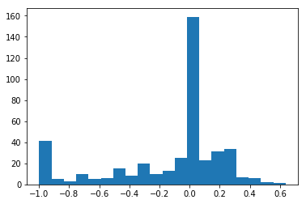

```
Gender
359
0
65
424
```

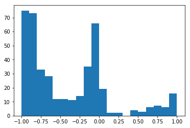

```
Age
175
0
249
424
```

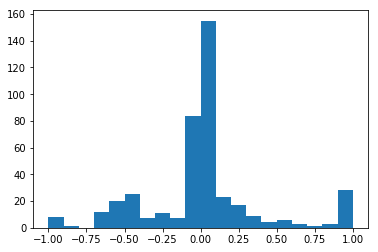

```
SibSp
257
0
167
424
```

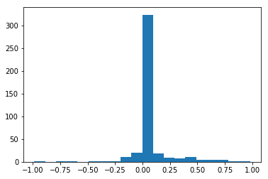

```
Parch
339
0
85
424
```

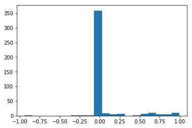

```
Fare
192
0
232
424
```

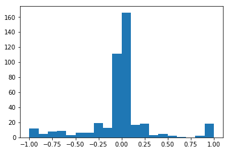

```
Embarked
395
0
29
424
```

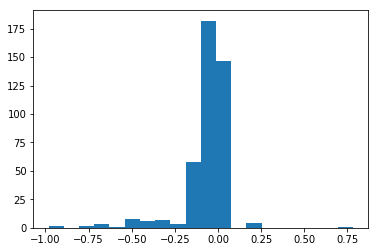

```
Gender
Survived
195
0
64
259
```

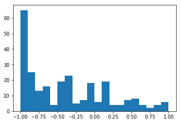

```
Pclass
130
0
129
259
```

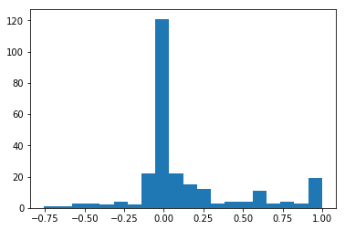

```
Age
160
0
99
259
```

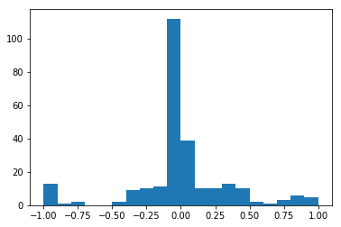

```
SibSp
113
0
146
259
```

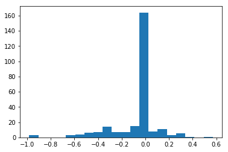

```
Parch
96
0
163
259
```

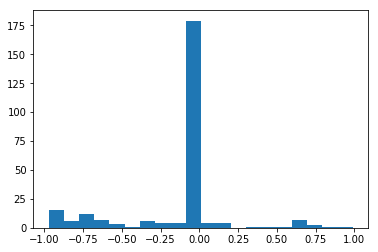

```
Fare
136
0
123
259
```

[9 more figures not shown]

```python
import matplotlib.pyplot as plt
for i in categoricals:
    print(spn.featureNames[i])
    query = np.where(numerical_data[:,i] == 0)
    gradients = f.gradient(spn, numerical_data[query], i)
    gradients_norm = np.linalg.norm(gradients, axis = 1).reshape(-1,1)
    reload(f)
    for j in range(spn.numFeatures - 1):
        print(spn.featureNames[[x for x in range(spn.numFeatures) if x != i][j]])
        _gradients = -(gradients/gradients_norm)[:,j]
        largest_neg  = len(np.where(_gradients <= -0.75)[0])
        large_neg    = len(np.where((_gradients > -0.75) & (_gradients <= -0.5))[0])
        small_neg    = len(np.where((_gradients > -0.5) & (_gradients <= -0.25))[0])
        smallest_neg = len(np.where((_gradients > -0.25) & (_gradients < 0))[0])
        zero         = len(np.where(_gradients == 0)[0])
        smallest_pos = len(np.where((_gradients > 0) & (_gradients < 0.25))[0])
        small_pos    = len(np.where((_gradients >= 0.25) & (_gradients < 0.5))[0])
        large_pos    = len(np.where((_gradients >= 0.5) & (_gradients < 0.75))[0])
        largest_pos  = len(np.where((_gradients >= 0.75))[0])
        print(sum([largest_neg, large_neg, small_neg, smallest_neg]))
        print(zero)
        print(sum([largest_pos, large_pos, small_pos, smallest_pos]))
        print(sum([largest_pos, large_pos, small_pos, smallest_pos, zero, largest_neg, large_neg, small_neg, smallest_neg]))
        plt.hist(_gradients, bins = 20)
        plt.show()
    print()
```

## Aknowledgments

This notebook is build on the MSPN implementation by Molina et.al. during the course of a bachelor thesis under the supervision of Alejandro Molina and Kristian Kersting at TU Darmstadt. The goal of this framework is to sum product networks for hybrid domains and to highlight important aspects and interesting features of a given dataset.

### Using this notebook

The whole notebook can be run as-is and will generate a complete report of the provided datasets. All parameters which have to be set are documented at the required locations, or in the configuration beforehand. The latter are mostly the rendering detail and similar variables which only influence the visual parts of the report.